# 2_ggplot2

2025-08-28

Cargamos la librería de ggplot2

```r
library(ggplot2)
```

Usar datos de vectores numericos

```r
x <- 1:10
y <- rnorm(10, 4.5, 0.1)
```

Explorar datos

```r
x
```

```
##  [1]  1  2  3  4  5  6  7  8  9 10
```

```r
y
```

```
##  [1] 4.373304 4.576751 4.365392 4.430663 4.377358 4.473828 4.523229 4.543747
##  [9] 4.352538 4.640293
```

Plot basico

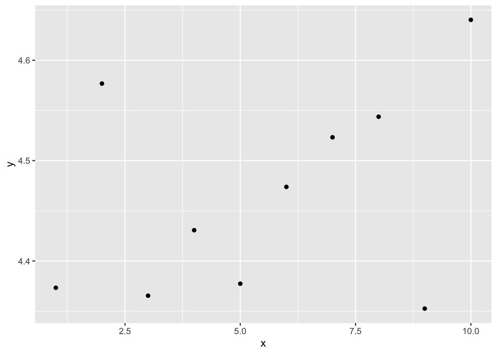

```r
qplot(x,y)
```

Añadir una linea

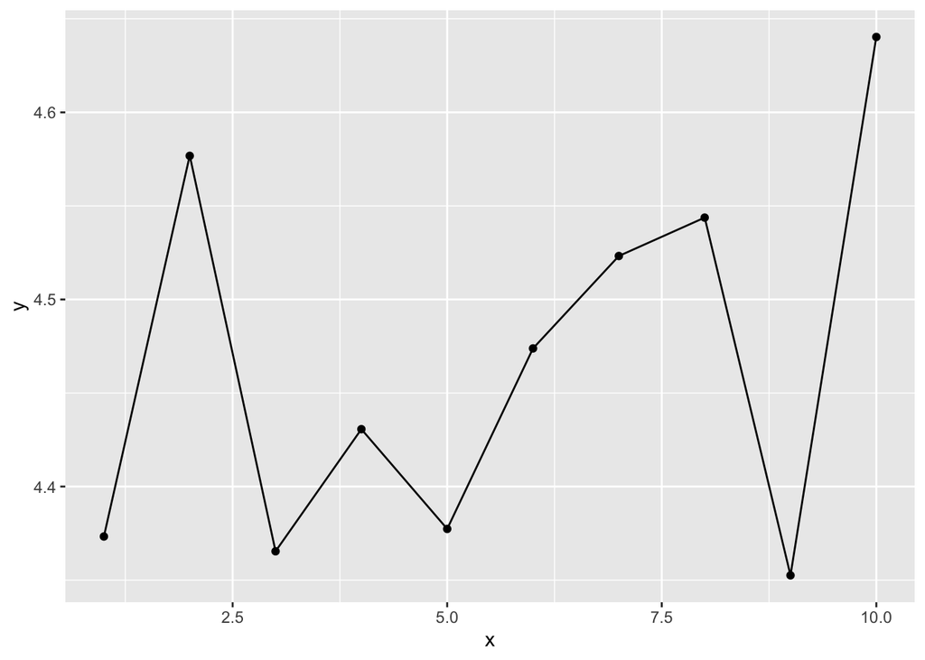

```r
qplot(x, y, geom=c("point", "line"))
```

Usar datos de un data.frame, “mtcars” se incluye en la libreria ggplot2 Explorar los datos

```r
?mtcars
```

```r
head(mtcars)
```

```
##                    mpg cyl disp  hp drat    wt  qsec vs am gear carb
## Mazda RX4         21.0   6  160 110 3.90 2.620 16.46  0  1    4    4
## Mazda RX4 Wag     21.0   6  160 110 3.90 2.875 17.02  0  1    4    4
## Datsun 710        22.8   4  108  93 3.85 2.320 18.61  1  1    4    1
## Hornet 4 Drive    21.4   6  258 110 3.08 3.215 19.44  1  0    3    1
## Hornet Sportabout 18.7   8  360 175 3.15 3.440 17.02  0  0    3    2
## Valiant           18.1   6  225 105 2.76 3.460 20.22  1  0    3    1
```

```r
summary(mtcars)
```

```
##       mpg             cyl             disp             hp
##  Min.   :10.40   Min.   :4.000   Min.   : 71.1   Min.   : 52.0
##  1st Qu.:15.43   1st Qu.:4.000   1st Qu.:120.8   1st Qu.: 96.5
##  Median :19.20   Median :6.000   Median :196.3   Median :123.0
##  Mean   :20.09   Mean   :6.188   Mean   :230.7   Mean   :146.7
##  3rd Qu.:22.80   3rd Qu.:8.000   3rd Qu.:326.0   3rd Qu.:180.0
##  Max.   :33.90   Max.   :8.000   Max.   :472.0   Max.   :335.0
##       drat             wt             qsec             vs
##  Min.   :2.760   Min.   :1.513   Min.   :14.50   Min.   :0.0000
##  1st Qu.:3.080   1st Qu.:2.581   1st Qu.:16.89   1st Qu.:0.0000
##  Median :3.695   Median :3.325   Median :17.71   Median :0.0000
##  Mean   :3.597   Mean   :3.217   Mean   :17.85   Mean   :0.4375
##  3rd Qu.:3.920   3rd Qu.:3.610   3rd Qu.:18.90   3rd Qu.:1.0000
##  Max.   :4.930   Max.   :5.424   Max.   :22.90   Max.   :1.0000
##        am              gear            carb
##  Min.   :0.0000   Min.   :3.000   Min.   :1.000
##  1st Qu.:0.0000   1st Qu.:3.000   1st Qu.:2.000
##  Median :0.0000   Median :4.000   Median :2.000
##  Mean   :0.4062   Mean   :3.688   Mean   :2.812
##  3rd Qu.:1.0000   3rd Qu.:4.000   3rd Qu.:4.000
##  Max.   :1.0000   Max.   :5.000   Max.   :8.000
```

Generar una gráfica con fines didácticos

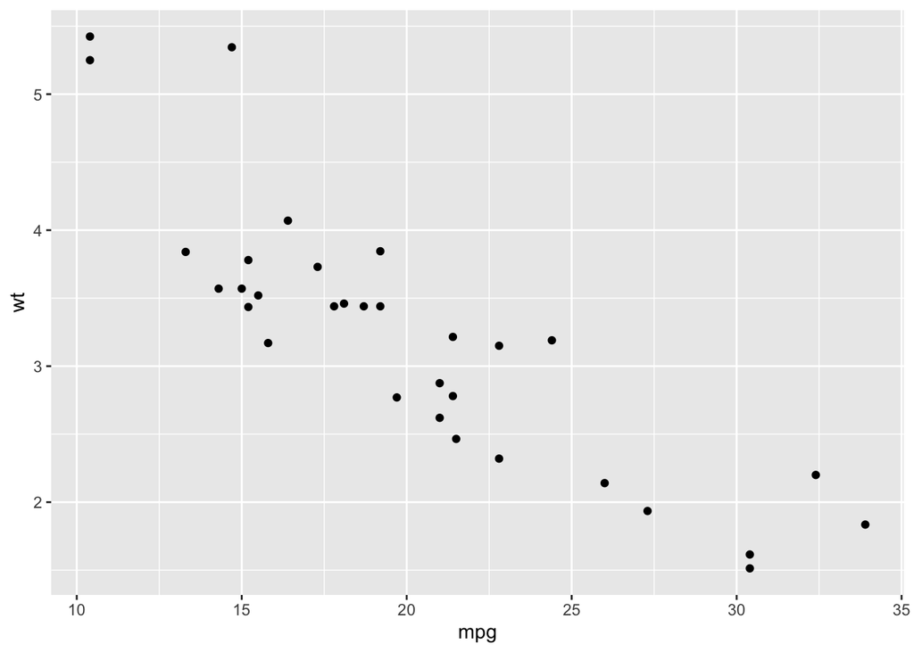

```r
qplot(x=mpg, y=wt, data=mtcars)
```

Smoothing (agregar una línea suavizada con su error estandar)

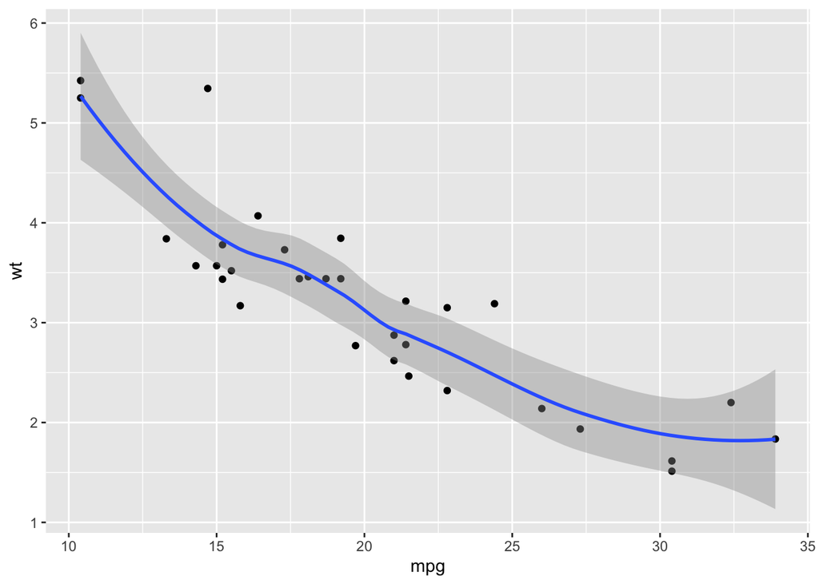

```r
qplot(x=mpg, y=wt, data = mtcars, geom = c("point", "smooth"))
```

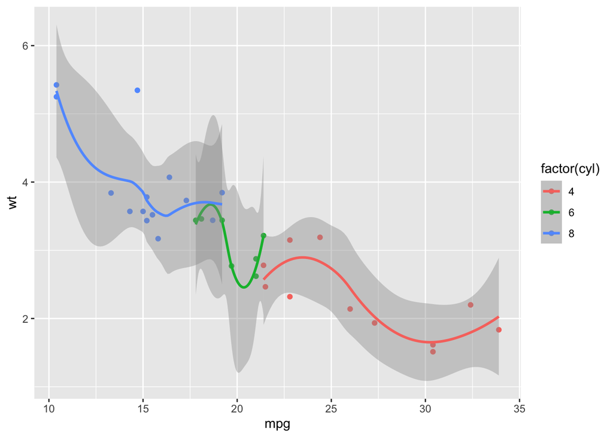

```r
qplot(x=mpg, y=wt, data = mtcars, color = factor(cyl), geom=c("point", "smooth"))
```

Cambiar el color por una variable numerica continua

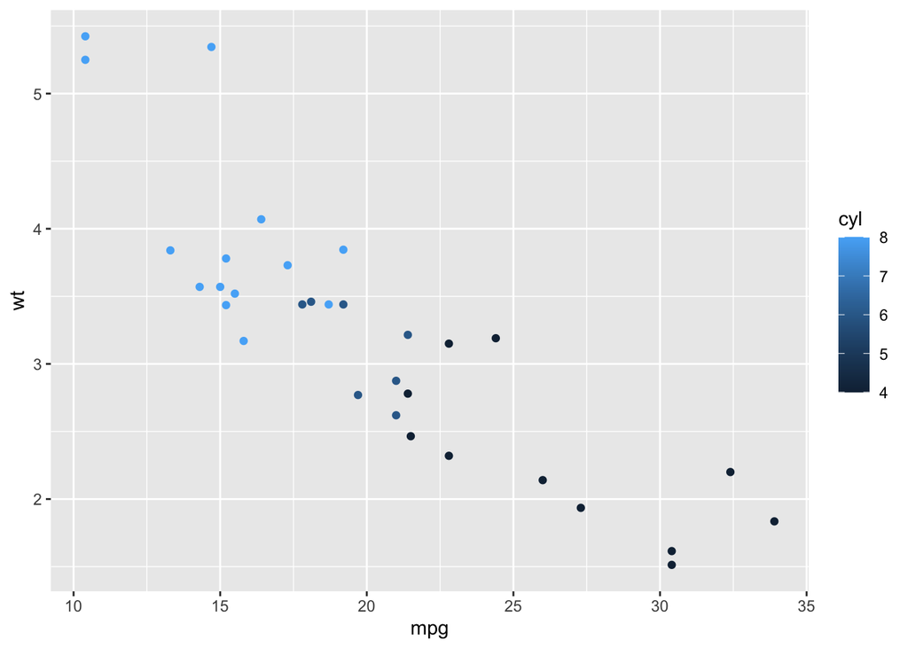

```r
qplot(x=mpg, y=wt, data = mtcars, colour = cyl)
```

Cambiar el color por grupos (factor)

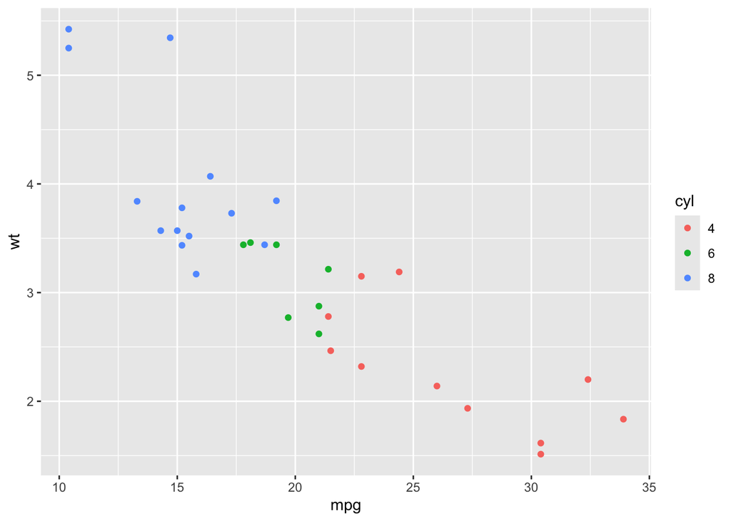

```r
df <- mtcars
df[,'cyl'] <- as.factor(df[,'cyl'])
qplot(x=mpg, y=wt, data = df, colour = cyl)
```

Añadir lineas

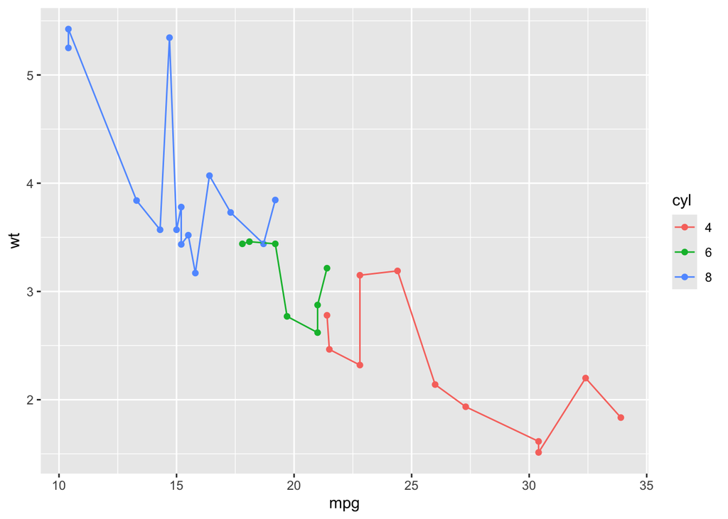

```r
qplot(mpg, wt, data = df, colour = cyl, geom=c("point", "line"))
```

Adiccion de temas

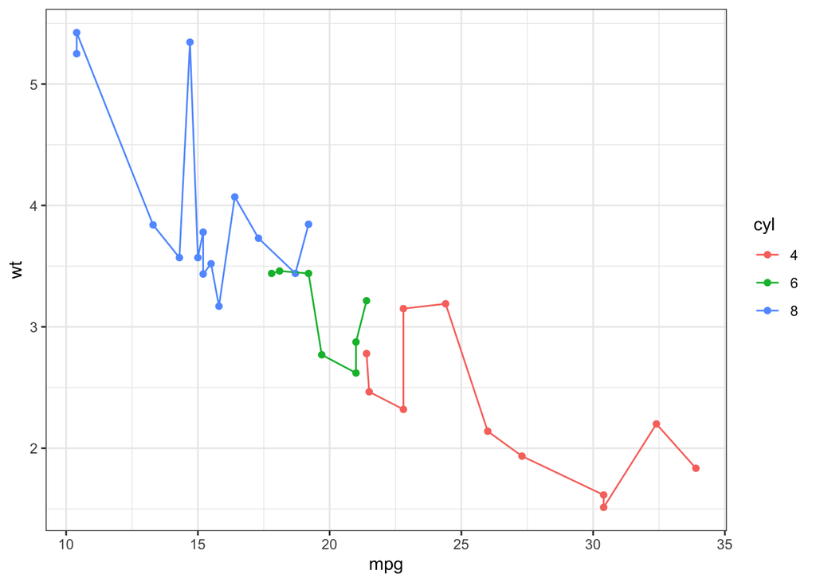

```r
qplot(mpg, wt, data = df, colour = cyl, geom=c("point", "line")) + theme_bw()
```

Regresamos al github